# Lesson 4: Describing Quantitative Data (Spread)

## Lesson Outcomes

Show/Hide Outcomes

## R Script

Here is a link to the R Script for Lesson 4.

## Spread of a Distribution

In the previous lesson, we introduced two important characteristics of a distribution: the **shape** and the **center**. In this section, you will discover ways to summarize the **spread** of a distribution of data. The spread of a distribution of data describes how far the observations tend to be from each other. There are many ways to describe the spread of a distribution, but one of the most popular measurements of spread is called the “standard deviation.”

### Standard Deviation

This activity introduces two measures of spread: the standard deviation and the variance.

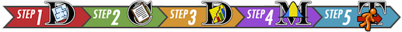

**Bird Flu Fever**

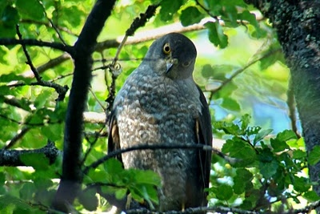

Avian Influenza A H5N1, commonly called the bird flu, is a deadly illness that is currently only passed to humans from infected birds. This illness is particularly dangerous because at some point it is likely to mutate to allow human-to-human transmission. Health officials worldwide are preparing for the possibility of a bird flu pandemic.

Dr. K. Y. Yuen led a team of researchers who reported the body temperatures of people admitted to Chinese hospitals with confirmed cases of Avian Influenza. Their research team collected data on the body temperature at the time that people with the bird flu were admitted to the hospital. In the article, they reported on two groups of people, those with relatively uncomplicated cases of the bird flu and those with severe cases.

The table below presents the data representative of the body temperatures for the two groups of bird flu patients:

| Relatively Uncomplicated Cases | Severe Cases |
| --- | --- |
| 38.1 | 39.1 |
| 38.3 | 39.5 |
| 38.4 | 38.9 |
| 39.5 | 39.2 |
| 39.7 | 39.9 |
|  | 39.7 |
|  | 39.0 |

Let us focus on the relatively uncomplicated cases. Creating a histogram of such a small dataset does not provide much benefit. With only a handful of values, there is not much shape to the distribution.

We can, however, use numerical summaries to give an indication of the center of the distribution.

Answer the following questions:

7. What is the median of the body temperatures for the relatively uncomplicated cases?

Show/Hide Solution

8. What is the mean of the body temperatures for the relatively uncomplicated cases?

Show/Hide Solution

We will use these data to investigate some measures of the spread in a data set.

There is relatively little difference in the temperatures of the uncomplicated patients. The lowest is $38.1 ^\circ \text{C}$, while the highest temperature is $39.7 ^\circ \text{C}$.

The **standard deviation** is a measure of the *spread* in the distribution. If the data tend to be close together, then the standard deviation is relatively small. If the data tend to be more spread out, then the standard deviation is relatively large.

The standard deviation of the body temperatures is $0.742 ^\circ \text{C}$. This number contains information from all the patients. If the patients’ temperatures had been more diverse, the standard deviation would be larger. If the patients’ temperatures were more uniform (i.e. closer together), then the standard deviation would have been smaller. If all the patients somehow had the same temperature, then the standard deviation would be zero.

We are working with a sample. To be explicit, we call $0.742 ^\circ \text{C}$ the *sample* standard deviation. The symbol for the sample standard deviation is $s$. This is a statistic. The parameter representing the *population* standard deviation is $\sigma$ (pronounced /SIG-ma/). In practice, we rarely know the value of the population standard deviation, so we use the sample standard deviation $s$ as an approximation for the unknown population standard deviation $\sigma$.

At this point, you probably do not have much intuition regarding the standard deviation. We will use this statistic frequently. By the end of the semester you can expect to become very comfortable with this idea. For now, all you need to know is that if two variables are measured on the same scale, the variable with values that are further apart will have the larger standard deviation.

### R Instructions for Computing the Standard Deviation

R Instructions

Show/Hide R Instructions

**Rounding:** As a general rule, when reporting your answers in this class, round to three decimal places unless otherwise specified.

### Calculating the Standard Deviation by Hand

How is the standard deviation computed? Where does this “magic” number come from? How does one number include the information about the spread of all the points?

It is a little tedious to compute the standard deviation by hand. You will usually compute standard deviation with a computer. However, the process is very instructive and will help you understand conceptually what the statistic represents. As you work through the following steps, please remember the goal is to find a measure of the spread in a data set. We want one number that describes how spread out the data are.

First, observe the number line below, where each x represents the temperature of a patient with a relatively uncomplicated case of bird flu. As mentioned earlier, there is not a huge spread in the temperatures.

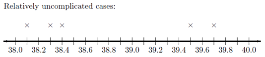

On your sketch of the number line, we draw a vertical line at 38.8 degrees, the sample mean. Now, draw horizontal lines from the mean to each of your $\times$’s. These horizontal line segments represent the spread of the data about the mean. Your plot should look something like this:

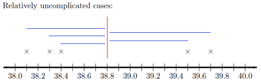

The length of each of the line segments represents how far each observation is from the mean. If the data are close together, these lines will be fairly short. If the distribution has a large spread, the line segments will be longer. The standard deviation is a measure of how long these lines are, as a whole.

The distance between the mean and an observation is referred to as a deviation. In other words, deviations are the lengths of the line segments drawn in the image above.

$$\begin{array}{1cl}
\text{Deviation} & = & \text{Value} - \text{Mean} \\
\text{Deviation} & = & x - \bar x
\end{array}$$

If the observed value is greater than the mean, the deviation is positive. If the value is less than the mean, the deviation is negative.

The standard deviation is a complicated sort of average of the deviations. Making a table like the one below will help you keep track of your calculations. Please participate fully in this exercise. Writing your answers at each step and developing a table as instructed will greatly enhance the learning experience. By following these steps, you will be able to compute the standard deviation by hand, and more importantly, understand what it is telling you.

**Step 1**: The first step in computing the standard deviation by hand is to create a table with three columns, like the following. The first column contains the observed data. The second column computes how far each of the observed data points has deviated from the sample mean, denoted $\bar{x}$. The third column computes the squared value of each of these deviations. In Step 1, only enter the observed data in the first column and compute the mean of that column.

| Observation ($x$) | Deviation from the Mean ($x-\bar x$) | Squared Deviation from the Mean $(x - \bar{x})^2$ |
| --- | --- | --- |
| $38.1$ |  |  |
| $38.3$ |  |  |
| $38.4$ |  |  |
| $39.5$ |  |  |
| $39.7$ |  |  |
| $\bar x = 38.8$ |  |  |

**Step 2**: The second column of the table contains the deviations from the mean. Each deviation is computed by subtracting the mean $\bar{x}$ from the observed data value. Since the mean $\bar{x} = 38.8$, that value is subtraced from each data point to fill in the second column of the table.

| Observation ($x$) | Deviation from the Mean ($x-\bar x$) | Squared Deviation from the Mean $(x - \bar{x})^2$ |
| --- | --- | --- |
| $38.1$ | $38.1-38.8 = -0.7$ |  |
| $38.3$ | $38.3-38.8 = -0.5$ |  |
| $38.4$ | $38.4-38.8 = -0.4$ |  |
| $39.5$ | $39.5-38.8 = 0.7$ |  |
| $39.7$ | $39.7-38.8 = 0.9$ |  |
| $\bar x = 38.8$ |  |  |

Answer the following questions:

9. How could we use this table to find the “typical” distance from each point to the mean? Think carefully about this, and then write down your answer before continuing.

Show/Hide Solution

10. We need a way to work with the negative deviations from the mean, so they do not cancel with the positive ones. What could we do? (Choose one of the four options below.)

Option #1: Take the absolute value of the deviations

Option #2: Square the deviations from the mean

Option #3: Delete all the negative deviations

Option #4: Do something entirely different

- Please do not go on to Step 3 until you have finished this exploration.

“Piled Higher and Deeper” by Jorge Cham

[figure not shown]

**Step 3**: Complete the third column of the table by squaring each of the deviations from the mean that were computed in **Step 2.**

| Observation ($x$) | Deviation from the Mean ($x-\bar x$) | Squared Deviation from the Mean $(x - \bar{x})^2$ |
| --- | --- | --- |
| $38.1$ | $38.1-38.8 = -0.7$ | $(-0.7)^2 = 0.49$ |
| $38.3$ | $38.3-38.8 = -0.5$ | $(-0.5)^2 = 0.25$ |
| $38.4$ | $38.4-38.8 = -0.4$ | $(-0.4)^2 = 0.16$ |
| $39.5$ | $39.5-38.8 = 0.7$ | $(0.7)^2 = 0.49$ |
| $39.7$ | $39.7-38.8 = 0.9$ | $(0.9)^2 = 0.81$ |
| $\bar x = 38.8$ | Sum $ = 0$ |  |

**Step 4**: Now, add up the squared deviations from the mean.

| Observation ($x$) | Deviation from the Mean ($x-\bar x$) | Squared Deviation from the Mean $(x - \bar{x})^2$ |
| --- | --- | --- |
| $38.1$ | $38.1-38.8 = -0.7$ | $(-0.7)^2 = 0.49$ |
| $38.3$ | $38.3-38.8 = -0.5$ | $(-0.5)^2 = 0.25$ |
| $38.4$ | $38.4-38.8 = -0.4$ | $(-0.4)^2 = 0.16$ |
| $39.5$ | $39.5-38.8 = 0.7$ | $(0.7)^2 = 0.49$ |
| $39.7$ | $39.7-38.8 = 0.9$ | $(0.9)^2 = 0.81$ |
| $\bar x = 38.8$ | Sum $ = 0$ | **Sum $ = 2.20$** |

The sum of the squared deviations is 2.20.

Answer the following questions:

11. Suppose that the researchers had collected body temperature data on 500 bird flu patients instead of 5. What would happen to the sum of the squared deviations, if the distribution of the data is the same for the 500 patients as the 5 patients?

Show/Hide Solution

12. What could we do to make sure the sample size does not inflate our estimate of the spread of the data?

Option #1: Divide by n

Option #2: Divide by n-1

Option #3: Neither of these

- Please do not go on until you have finished this exercise.

**Step 5**: Take the value of the sum of the squared deviations that was computed in **Step 4** and divide it by $n - 1$. The value of $n$ is the sample size (the number of observed data values). The value of $n-1$ is called the degrees of freedom.

The sum of the squared deviations computed in **Step 4** was 2.20. Dividing $2.20$ by the number of observed data points ($5$) minus $1$, $n-1 = 5-1 = 4$, we get the value of the sample variance, $s^2$:

$$\underbrace{s^2 = \frac{sum}{n-1} = \frac{2.20}{5-1} = \frac{2.20}{4} = 0.55}_\text{sample variance}$$

The number computed in Step 5 is called the **sample variance**. It is a measure of the spread in a data set. It has very nice theoretical properties, but is not very useful for interpretation or an intuitive undstanding of the data. While the variance plays an important role in statistics, it is not a measurement that will be used very often in this introductory course. The sample variance is denoted by the symbol $s^2$.

It can be shown that the sample variance is an unbiased estimator of the true population variance (which is denoted $\sigma^2$.) This means that the sample variance can be considered a reasonable estimator of the population variance. If the sample size is large, this estimator tends to be very good.

Answer the following questions:

13. The temperature data for the bird flu patients are in degrees Centigrade. What are the units of the variance?

Show/Hide Solution

14. What operation can we do to the variance to get a quantity with units degrees Centigrade?

Show/Hide Solution

**Step 6**: Compute the standard deviation by taking the square root of the sample variance. The standard deviation is a very interpretable number as it gives the “typical” or “standard” deviation of the observed data from the mean. It gives a good feel for how spread out the data is from the mean.

$$\underbrace{s = \sqrt{ s^2 } = \sqrt{\strut\text{Sample Variance}} = \sqrt{0.55} \approx 0.742}_\text{Sample Standard Deviation}$$

The standard deviation has the same units as the original observations. We use the standard deviation heavily in statistics and in this course.

The sample standard deviation ($s$) is an estimate of the true population standard deviation ($\sigma$).

Answer the following questions:

15. What is the sample standard deviation, $s$, of the temperatures of the five patients with relatively uncomplicated cases of the bird flu?

Show/Hide Solution

**Summary**

**Standard Deviation**

The **standard deviation** is one number that describes the spread in a set of data. If the data points are close together the standard deviation will be smaller than if they are spread out.

At this point, it may be difficult to understand the meaning and usefulness of the standard deviation. For now, it is enough for you to recognize the following points:

- The standard deviation is a measure of how spread out the data are.
- If the standard deviation is large, then the data are very spread out.
- If the standard deviation is zero, then all the values are the identical–there is no spread in the data.
- The standard deviation cannot be negative.

### Variance

The variance is the square of the standard deviation. The sample variance is denoted by the symbol $s^2$. You found the sample standard deviation for patient temperatures of uncomplicated cases of bird in the bird above is $s = 0.74162$. So, the sample variance for this data set is $s^2 = 0.74162^2 = 0.550$. Be aware, if you had squared the rounded value of $s^2 = 0.742$ in the calculation, you would have gotten an answer of 0.551 instead. This would be considered incorrect!

### R Instructions for Computing the Sample Variance

R Instructions

Show/Hide R Instructions

The standard deviation and variance are two commonly used measures of the spread in a data set. Why is there more than one measure of the spread? The standard deviation and the variance each have their own pros and cons.

The variance has excellent theoretical properties. It is an unbiased estimator of the true population variance. That means that if many, many samples of $n$ observations were drawn, the variances computed for all the samples would be centered nicely around the true population variance, $\sigma^2$. Because of these benefits, the variance is regularly used in higher-level statistics applications. One drawback of the variance is that the units for the variance are the square of the units for the original data. In the bird flu example, the body temperatures were measured in degrees Centigrade. So, the variance will have units of degrees Centigrade squared $(^\circ \text{C})^2$. What does degrees Centigrade squared mean? How do you interpret this? It doesn’t make any sense. This is one of the major drawbacks of the sample variance.

Because we take the square root of the variance to get the standard deviation, the standard deviation is in the same units as the original data. This is a great advantage, and is one of the reasons that the standard deviation is commonly used to describe the spread of data.

Answer the following questions:

Enter the patient temperature data for the severe cases of bird flu into R. Then use R to calculate the numerical summaries you have learned so far. As a reminder, the temperatures of patients with a severe case of bird flu are:

39.1, 39.5, 38.9, 39.2, 39.9, 39.7, 39

16. What is the mean, median, standard deviation and variance of the sample?

Show/Hide Solution

For the next two questions, consider the histograms below comparing weight (in kilograms) of men (top histogram) to elephant seals (bottom histogram).

Weight of Men Compared to Weight of Seals

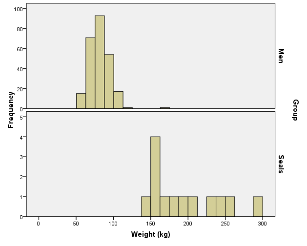

17. Based on the histograms, who has a greater sample mean weight, men or elephant seals?

Show/Hide Solution

18. Based on the histograms, do the weights of men or elephant seals have a larger sample standard deviation?

Show/Hide Solution

**Review of Parameters and Statistics**

We have now learned some statistics that can be used to estimate population parameters. For example, we use $\bar x$ to estimate the population mean $\mu$. The sample statistics $s$ estimates the true population standard deviation $\sigma$. The following table summarizes what we have done so far:

| Measurement | Sample Statistic | Population Parameter |
| --- | --- | --- |
| Mean | $\bar x$ | $\mu$ |
| Standard Deviation | $s$ | $\sigma$ |
| Variance | $s^2$ | $\sigma^2$ |

Unless otherwise specified, we will always use R to find the sample variance and sample mean, but knowing how to compute them “by hand” helps you understand what these values measure.

In each case, the sample statistic estimates the population parameter.

**Optional Reading: Formulas for $s$ and $s^2$ (Hidden)**

Click Here if you love Math

** Outliers **

Neither the standard deviation nor the variance is **resistant** to outliers. This means that when there are outliers in the data set, the standard deviation and the variance become artificially large. It is worth noting that the mean is also not resistant. When there are outliers, the mean will be “pulled” in the direction of the outliers.

The mean and standard deviation are used to describe the center and spread when the distribution of the data is symmetric and bell-shaped. If data are not symmetric and bell-shaped, we typically use the five-number summary (discussed below) to describe the spread, because this summary is resistant.

## Additional Tools to Describe the Data

Recall the five steps of the Statistical Process (and the mnemonic “Daniel Can Discern More Truth).

| Step 1: | **D**aniel | **D**esign the study |
| --- | --- | --- |
| Step 2: | **C**an | **C**ollect data |
| Step 3: | **D**iscern | **D**escribe the data |
| Step 4: | **M**ore | **M**ake inferences |
| Step 5: | **T**ruth | **T**ake action |

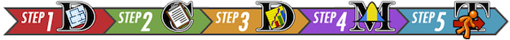

**Step 3** of this process is “**Describe the data**.” You have already learned about the mean, median, mode, standard deviation, variance and histograms. These can be good ways to describe the data. The following information on percentiles, quartiles, 5-number summaries, and boxplots will help you learn other common ways to describe data, especially if the data are skewed or contain outliers.

Now, you have probably had some experience with percentiles in the past especially when you received a score on a standardized test such as the ACT. Even though percentiles are commonly used, they are generally misunderstood. Before examining the wrong site/wrong patient data, let’s review percentiles. Even if you think you understand percentiles, please study this section carefully.

### Percentiles and Quartiles

Imagine students in a classroom on campus lining up in a line from shortest to tallest. The students are organized with the shortest student on the left and the tallest student on the right.

Answer the following question:

19. If there are 100 students in line, and we draw a line on the floor between each student, how many lines are needed to separate the 100 students?

Show/Hide Solution

The student heights are representative of all data. If we have a list of data, sorted in increasing order, and we want to divide it into 100 equal groups, we only need 99 dividers (like lines on a floor) to divide up the data. The first divider is as large or larger than 1% of the data. The second divider is as large or larger than 2% of the data, and so on. The last divider, the 99<sup>th</sup>, is the value that is as large or larger than 99% of the data. These dividers are called percentiles. A **percentile** is a number such that a specified percentage of the data are at or below this number. For example, the 99<sup>th</sup> percentile is a number such that 99% of the data are at or below this value. As another example, half (50%) of the data lie at or below the 50<sup>th</sup> percentile. The word percent means $\div 100$. This can help you remember that the percentiles divide the data into 100 equal groups.

So, if there were 100 students in a line from shortest to tallest, the height of the 5th student would be the 5th percentile of heights for those students.

**Quartiles** are special percentiles. The word quartile is from the Latin *quartus*, which means “fourth.” The quartiles divide the data into four equal groups. The quartiles correspond to specific percentiles. The first quartile, Q<sub>1</sub>, is the 25<sup>th</sup> percentile. The second quartile, Q<sub>2</sub>, is the same as the 50<sup>th</sup> percentile or the median. The third quartile, Q<sub>3</sub>, is equivalent to the 75<sup>th</sup> percentile.

Answer the following questions:

20. How many quartiles are there?

Show/Hide Solution

**Wrong Site/Wrong Patient Lawsuits**

Percentiles can be used to describe the center and spread of any distribution and are particularly useful when the distribution is skewed or has outliers. To explore this issue, you will use software to calculate percentiles of data on costs incurred by hospitals due to certain lawsuits. The lawsuits in question were about surgeries performed on the wrong patient, or on the right patient but the wrong part of the patient’s body (the wrong site).

### R Instructions for Computing Percentiles

R Instructions

Show/Hide R Instructions

The first quartile ($Q_1$) or 25<sup>th</sup> percentile (calculated in R) of the wrong-site data is: $29,496. This means that 25 percent of the time hospitals lost a wrong-site lawsuit, they had to pay $29,496 or less. The 25<sup>th</sup> percentile can be written symbolically as: P<sub>25</sub> = $29,496. Other percentiles can be written the same way. The 99<sup>th</sup> percentile can be written as P<sub>99</sub>.

Answer the following questions:

21. What is the 13<sup>th</sup> percentile of the wrong site data?

Show/Hide Solution

22. How would you interpret the 13<sup>th</sup> percentile (assuming the 13<sup>th</sup> percentile is $6343.40)?
- 1. 100 of the lawsuits cost more than 13%.
- 2. 13% of the lawsuits cost the hospital over $6343.40.
- 3. In 13% of the wrong-site lawsuits, hospitals had to pay $6343.40 or less.
- 4. For 13% of the wrong-site lawsuits, the hospitals had to pay $6343.40 to the patient.

Show/Hide Solution

23. Find P<sub>90</sub>.

Show/Hide Solution

24. The quartiles divide a sorted list of data into four equal groups. So, each group contains 25% of the data. The first quartile is the value that is greater than or equal to 25% of the data. What is another name for this number?

Show/Hide Solution

25. What is the value of the third quartile?

Show/Hide Solution

26. Half of the wrong-site lawsuits judgments were less than or equal to what value?

Show/Hide Solution

27. The median is the middle observation in a sorted list of data. What percentile is always equal to the median?

Show/Hide Solution

### The Five-Number Summary

Another way to summarize data is with the five-number summary. **The five-number summary** is comprised of the minimum, the first quartile, the second quartile (or median), the third quartile, and the maximum.

Statistical packages can give different results for some computations. This is because there are several reasonable ways to define certain quantities, such as the quartiles. As such, you may find that some of the values that are given in R are different than what other software may give.

### R Instructions for Computing Quartiles and the Five-number Summary

R Instructions

Show/Hide R Instructions

Answer the following questions:

28. Give the five-number summary for the Wrong Site data. (Remember that the mean is not part of the five-number summary.)

Show/Hide Solution

Some students mistakenly include the mean in the five-number summary. The third value in the five-number summary is the median.

### Boxplots

A **boxplot** is a graphical representation of the five-number summary. Unlike the mean or standard deviation, a boxplot is resistant to outliers. That means that it won’t be “pulled” one way or the other by extraordinarily large or small values in the data as will a mean, for instance. We will illustrate the process of making a boxplot using the wrong-site data.

Follow the steps below to learn how a boxplot relates to the five-number summary. Learning what each part of the boxplot represents will enable you to interpret the plot correctly.

**Step 1:** To draw a boxplot, start with a number line.

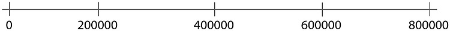

**Step 2:** Draw a vertical line segment above each of the quartiles.

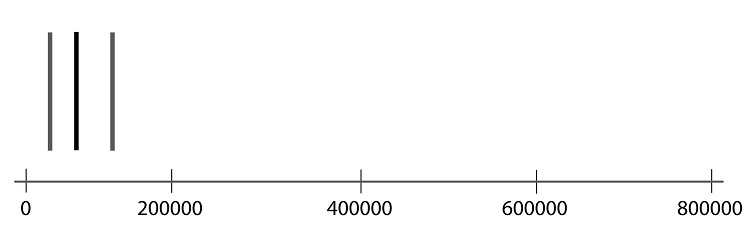

**Step 3:** Connect the tops and bottoms of the line segments, making a box.

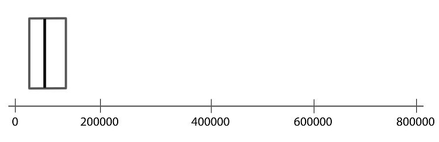

**Step 4:** Make a smaller mark above the values corresponding to the minimum and the maximum.

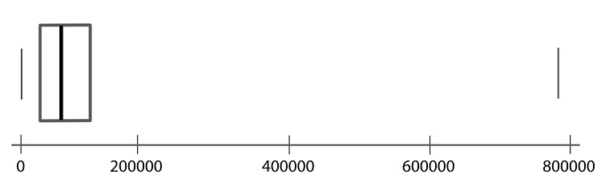

**Step 5:** Draw a line from the left side of the box to the minimum, and draw another line from the right side of the box the maximum.

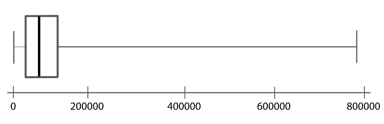

**Step 6:** These last two lines look like whiskers, so this is sometimes called a box-and-whisker plot.

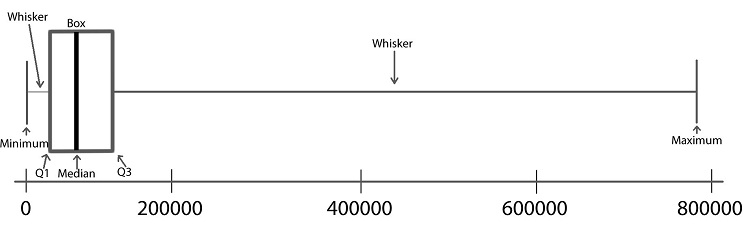

### R Instructions for Creating Boxplots

R Instructions

Show/Hide R Instructions

Answer the following questions:

29. Create a histogram of the **wrong-patient** lawsuit data, located in column B of the “surgery_lawsuits” data frame. What is the shape of the wrong-patient data?
1. Skewed left
2. Symmetric
3. Skewed right
4. Multi-modal
5. Uniform

Show/Hide Solution

30. Create a boxplot of the **wrong-patient** lawsuit data.

Show/Hide Solution

Side-by-side boxplots are a powerful way to compare data from different samples visually. For example, we may be interested in comparing the results of wrong-site lawsuits and wrong-patient lawsuits.

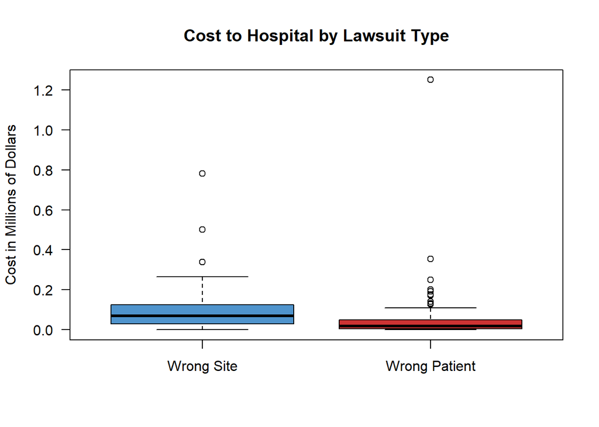

In the plot we can quickly see that a wrong-patient lawsuit resulted in the largest cost to the hospital, more than $1.2 million. However, in general, wrong-patient lawsuits tend to result in a lower cost to the hospital than wrong-site lawsuits.

R Instructions

Show/Hide R Instructions

### R Instructions for *NA* or Missing Values

Sometimes the data you are working with has missing values in it. These are recorded in R as `NA` values. Missing values can cause problems with calculations, but usually the `na.rm = TRUE` option can be used to remove the missing values and fix the calculations.

R Instructions

Show/Hide R Instructions

## Summary

Remember…

- The **standard deviation** is a number that describes how spread out the data are. A larger standard deviation means the data are more spread out than data with a smaller standard deviation. The smallest the standard deviation can be is zero, in which case all of the data is exactly the same.
- The standard deviation can be easily computed in R, where the six steps are performed automatically with the `sd(...)` function. However, the six steps to computing standard deviation by hand are:
  1. List out the observed data and compute the mean.
  2. Subtract the mean from each observed data value to obtain the deviations from the mean.
  3. Square each of the deviations from the mean.
  4. Sum the squared deviations.
  5. Divide the sum of the squared deviations by $n-1$. (This gives the sample variance.)
  6. Take the square root of the sample variance to obtain $s$, the sample standard deviation.
- **Quartiles/percentiles**, **Five-Number Summaries**, and **Boxplots** are tools that help us understand data. The five-number summary of a data set contains the minimum value, the first quartile, the median, the third quartile, and the maximum value. A boxplot is a graphical representation of the five-number summary.
- R functions that were discussed in this lesson include:
  - how to use `sd(...)` to compute the standard deviation in R.
  - how to use `quantile(..., 0.2)` to compute the 20<sup>th</sup> percentile in R. Change 0.2 to any other number between 0 and 1 to compute any other percentile.
  - how to use `summary(...)` to obtain the five-number summary in R.
  - how to use `boxplot(...)` to create a boxplot in R.
  - how to use the option `na.rm = TRUE` to remove `NA` or missing values from the data when using any of the functions `mean(..., na.rm = TRUE)`, `median(..., na.rm = TRUE)`, `sd(..., na.rm = TRUE)`, `quantile(..., na.rm = TRUE)`.

## Navigation

| **Previous Reading** | **This Reading** | **Next Reading** |
| --- | --- | --- |
| Lesson 3: Describing Quantitative Data (Shape and Center) | Lesson 4: Describing Quantitative Data (Spread) | Lesson 5: Normal Distributions |